# Artificial Intelligence - coursework 2

#### Daniela Nogueira

January, 2022

# Neural style transfer

Neural style transfer is an optimisation technique that combines two images - a content image and a style reference image, such as a famous painter's work of art - to create an output image that appears like the content image but is "painted" in the manner of the style reference image. This technique was introduced by Leon Gatys et al. in the summer of 2015 ("A Neural Algorithm of Artistic Style").

In this context, style refers to the image's textures, colours, and visual patterns at various spatial scales, whereas content refers to the image's higher-level macrostructure.

The idea behind implementing style transfer is the same as it is for all deep-learning algorithms: we define a loss function to specify what you want to achieve, which in this case is preserving the content of the original image while adopting the style of the reference image, and then we minimise that loss.

In this sense the loss function can be defined as:

#### Loss = distance(style(reference_image) - style(generated_image)) + distance(content(original_image) - content(generated_image))

Distance is the norm function such as L2 norm; content is a function that takes an image and computes a representation of its content; and style is a function that takes an image and computes a representation of its style. As a result of minimising the loss, style (generated image) approaches style (reference image), and content (generated image) approaches content (original image).

## Libraries

```python
import tensorflow as tf
from keras.preprocessing.image import img_to_array
from PIL import Image
import matplotlib.pyplot as plt
import matplotlib as mpl
from keras.applications import vgg19
import numpy as np
from tensorflow.keras.applications import vgg19
from tensorflow.keras.models import Model
from tensorflow.python.keras import models
from tensorflow.python.keras import losses
from tensorflow.python.keras import layers
from tensorflow.python.keras import backend as K
import functools
import IPython.display as display
import time
mpl.rcParams['figure.figsize'] = (12, 12)
mpl.rcParams['axes.grid'] = False
```

## 1. Prepare Data

### 1.1. Load File

#### Define a function to load an image, limit its maximum dimension to 512 pixels and return a numpy array

We resize and limit the maximum dimension of the images to ensure that they have all similar sizes. Style transfer is more difficult when the sizes are vastly different.

```python
def load_image(image_path):

    img = Image.open(image_path)
    width, height = img.size
    max_dim = 512
    scale = max_dim/max(img.size)
    #Anti-aliasing is the smoothing of jagged edges in digital images by averaging the colors of the pixels at a boundary
    image = img.resize((round(width*scale),round(height*scale)),Image.ANTIALIAS)
    image_array = img_to_array(image)
    #The expand_dims function adds a dimension to represent a number of images in the input
    image_array = np.expand_dims(image_array,axis=0)

    return image_array
```

#### Create a simple function to display an image

```python
def show_image(image, title=None):

    #Remove all dimensions of size 1 from the NumPy array
    img = np.squeeze(image,axis=0)
    plt.imshow(np.uint8(img))
    if title:
        plt.title(title)
```

#### Plot Image

[figure not shown]

```python
content_image  = load_image('content.jpg')
style_image = load_image('style.jpg')

plt.subplot(1,2,1)
show_image(content_image,'Content Image')

plt.subplot(1,2,2)
show_image(style_image,'Style Image')

plt.show()
```

### 1.2. Data Preprocessing

#### Define a function to process image for input to vgg19 model

This preprocess input function (used in VGG 19) converts RGB to BGR images and centres them around 0 based on ImageNet data (no scaling).

```python
def preprocess_image(img_path):

    image = load_image(img_path)
    #This preprocess_input function (used in VGG 19 ) converts the input RGB to BGR images and centre these values around 0 according to ImageNet data (no scaling).
    img = vgg19.preprocess_input(image)

    return img
```

#### Define function to deprocess image

The deprocess function takes an image as input and performs the inverse of the preprocess input function we imported before.

```python
def deprocess_img(processed_image):

    x = processed_image.copy()
    #remove one dimension if image has 4 dimension
    if len(x.shape) == 4:
        x = np.squeeze(x, axis=0)

    #Input dimension must be [1, height, width, channel] or [height, width, channel]
    assert len(x.shape) == 3

    #Perform the inverse of the pre processing step. Remove zero-center by mean pixel
    x[:, :, 0] += 103.939
    x[:, :, 1] += 116.779
    x[:, :, 2] += 123.68

    #'BGR'->'RGB'
    x = x[:, :, ::-1]
    x = np.clip(x, 0, 255).astype('uint8')

    return x
```

## 2. Loss Functions

### 2.1. Content loss

The definition of content loss is actually fairly straightforward. We'll send both the desired content image and our base input image to the network. This will return the intermediate layer outputs from our model (from the layers we'll define). The euclidean distance between the two intermediate representations of those images is then calculated. To put it another way, content loss is a function that describes the distance between our input image and our content image in terms of content.

We'll perform backpropagation in order to minimise content loss. As a result, we alter the initial image until it provides a comparable response in a certain layer/layers (which we'll define later in content layers) as the original content image.

The get_content_loss function will calculate the mean square difference between the feature maps of generated and content images.

```python
def get_content_loss(combination,base):

    #tf.reduce_mean(input_tensor) reduces input_tensor along the dimensions given in axis by computing the mean of elements across the dimensions in axis
    content_loss = tf.reduce_mean(tf.square(combination - base))

    return content_loss
```

### 2.2. Style loss

```python
def gram_matrix(input_tensor):

    # We make the image channels first
    channels = int(input_tensor.shape[-1])
    vector = tf.reshape(input_tensor,[-1,channels])
    n = tf.shape(vector)[0]
    gram_matrix = tf.matmul(vector,vector,transpose_a=True)

    return gram_matrix/tf.cast(n,tf.float32)

def get_style_loss(combination, base):

    gram_style = gram_matrix(combination)
    style_loss = tf.reduce_mean(tf.square(base-gram_style))

    return style_loss
```

Now, I am going to create a function that will load our content and style images, send them via our network, and then output our model's content and style feature representations.

```python
def get_features(model,content_path,style_path):

    content_img = preprocess_image(content_path)
    style_img = preprocess_image(style_path)

    #Batch compute content and style features
    content_output = model(content_img)
    style_output = model(style_img)

    #Get the style and content feature representations from our model
    content_feature = [layer[0] for layer in content_output[number_style:]]
    style_feature = [layer[0] for layer in style_output[:number_style]]

    return content_feature,style_feature
```

### 2.3. Total loss

This function will compute the total loss.

Arguments:

- model: The model that will give us access to the intermediate layers
- Loss_weights: The weights of each contribution of each loss function (style weight and content weight).
- init_image: Our initial base image. This image is what we are updating with our optimisation process. We apply the gradients on this image in relation to the loss we're computing.
- gram_style_features: Precomputed gram matrices corresponding to the defined style layers of interest.
- content_features: Precomputed outputs from defined content layers of interest.

```python
def compute_loss(model, loss_weights, init_image, gram_style_features, content_features):

    #Style weight and content weight are user given parameters that define what percentage of content and style will be preserved in the generated image
    style_weight, content_weight = loss_weights

    #Feed our init image through our model. This will give us the content and  style representations at our desired layers.
    output = model(init_image)
    content_loss=0
    style_loss=0


    style_output_features = output[:number_style]
    content_output_features = output[number_style:]

    #Accumulate style losses from all layers
    #Here, we equally weight each contribution of each loss layer
    weight_per_style_layer = 1.0/float(number_style)
    for target_style, combination_style in zip(gram_style_features,style_output_features):
        style_loss +=  weight_per_style_layer*get_style_loss(combination_style[0], target_style)


    #Accumulate content losses from all layers
    #Here, we equally weight each contribution of each loss layer
    weight_per_content_layer = 1.0 / float(number_content)
    for target_content, combination_content in zip(content_features,content_output_features):
        content_loss += weight_per_content_layer* get_content_loss(combination_content[0], target_content)

    style_loss *= style_weight
    content_loss *= content_weight

    total_loss = content_loss + style_loss

    return total_loss, style_loss, content_loss
```

## 3. Gradient descend

To compute the gradient, we use tf.GradientTape. It enables us to use the automatic differentiation provided by tracing operations to calculate the gradient afterwards. It records the operations during the forward pass and then is able to compute the gradient of our loss function with respect to our input image for the backwards pass.

```python
def compute_grads(dictionary):
    with tf.GradientTape() as tape:
        all_loss = compute_loss(**dictionary)
    #Compute gradients with regard to input image
    total_loss = all_loss[0]
    return tape.gradient(total_loss,dictionary['init_image']), all_loss
```

## 4. Models experiments

As we already know, earlier layers of a network include local information about the image, but higher layers contain increasingly global, abstract information. The activations of the multiple layers of a convnet give a deconstruction of the contents of an image over different spatial scales. As a result, we'd expect the representations of the upper layers in a convnet to capture the content of an image, which is more global and abstract.

In general, content loss uses only one upper layer, whereas style loss use multiple layers of a convnet. We strive to capture the style-reference image's appearance at all spatials cales extrated by the convnet, not just one.

We can adjust the content weight, which is the content loss's contribution to the total loss, and the style weight depending on the style-reference image and content image. A higher content weight means the target content will be more recognisable in the generated image. We'll play around with that in the next experiments.

### 4.1. Model 1: Beating the baseline ¶

To beat the baseline, a small model is being developed. The goal of this. neural style transfer is to transfer some texture, pattern, or even colour from our style reference image to our content image.

| Model | Epochs | content_layers | style_layers | content_weight | style_weight |
| --- | --- | --- | --- | --- | --- |
| 1 | 9 | block3_conv2 | block3_conv1 | 1e+2 | 1e-3 |

#### Choose content and style layers

```python
#Layers used for content loss
content_layers = ['block3_conv2']
#Layers used for style loss
style_layers = ['block3_conv1']

number_content = len(content_layers)
number_style = len(style_layers)
```

#### Model

In this scenario, we load VGG19 and feed the model our input tensor. This will allow us to extract the content, style, and generated image feature maps and, as a result, the content and style representations.

As suggested in the book "Deep Learning With Python", we use VGG19. Furthermore, because VGG19 is a very simple model in comparison to ResNet, Inception, and other models, the feature maps function well for neural style transfer. We retrieve the necessary outputs by using the Keras Functional API to define our model with the desired output activations in order to access the intermediate layers corresponding to our style and content feature maps.

Declaring a model with the Functional API is as simple as defining the input and output: model = model (inputs, outputs).

In the code below, we’ll load our pre-trained image classification network. Then we grab the layers of interest as we previously defined . Then we define a Model by setting the model’s inputs to an image and the outputs to the outputs of the style and content layers. To put it another way, we built a model that takes an input image and output the content and style intermediate layers.

```python
def get_model():

    """
    Creates our model with access to intermediate layers.

    This function will load the VGG19 model and access the intermediate layers.
    These layers will then be utilised to build a new model that takes an input image and returns the outputs of the VGG model's intermediate layers.

    Return: keras model that accepts image input and outputs the style and content intermediate layers.

    """
    #Load our model. We load pretrained VGG, trained on imagenet data (weights=’imagenet’)
    vgg = tf.keras.applications.vgg19.VGG19(include_top=False, weights='imagenet')
    vgg.trainable = False

    #Get output layers corresponding to style and content layers
    content_output=[vgg.get_layer(layer).output for layer in content_layers]
    style_output=[vgg.get_layer(layer).output for layer in style_layers]
    model_output= style_output + content_output

    #Build model
    return models.Model(vgg.input, model_output)
```

```python
model = get_model()
model.summary()
```

```
Model: "model_1"
_________________________________________________________________
Layer (type)                 Output Shape              Param #
=================================================================
input_2 (InputLayer)         [(None, None, None, 3)]   0
_________________________________________________________________
block1_conv1 (Conv2D)        (None, None, None, 64)    1792
_________________________________________________________________
block1_conv2 (Conv2D)        (None, None, None, 64)    36928
_________________________________________________________________
block1_pool (MaxPooling2D)   (None, None, None, 64)    0
_________________________________________________________________
block2_conv1 (Conv2D)        (None, None, None, 128)   73856
_________________________________________________________________
block2_conv2 (Conv2D)        (None, None, None, 128)   147584
_________________________________________________________________
block2_pool (MaxPooling2D)   (None, None, None, 128)   0
_________________________________________________________________
block3_conv1 (Conv2D)        (None, None, None, 256)   295168
_________________________________________________________________
block3_conv2 (Conv2D)        (None, None, None, 256)   590080
=================================================================
Total params: 1,145,408
Trainable params: 0
Non-trainable params: 1,145,408
_________________________________________________________________
```

#### Apply and run the style transfer process

```python
def run_style_transfer(content_path,style_path,epochs,content_weight, style_weight):

    model = get_model()

    #We don't need to (or want to) train any layers of our model, so we set their trainability to false.
    for layer in model.layers:
        layer.trainable = False

    #Get the style and content feature representations (from our specified intermediate layers)
    content_feature, style_feature = get_features(model,content_path,style_path)
    style_gram_matrix = [gram_matrix(feature) for feature in style_feature]

    #Set initial image
    init_image = preprocess_image(content_path)
    init_image = tf.Variable(init_image,dtype=tf.float32)

    #Create our optimizer
    optimizer = tf.keras.optimizers.Adam(learning_rate=5, beta_1=0.99, epsilon=1e-1)

    #Store our best result
    best_loss, best_img = float('inf'), None

    #Create a nice configuration
    loss_weights = (style_weight, content_weight)
    dictionary={'model': model,
              'loss_weights': loss_weights,
              'init_image': init_image,
              'gram_style_features': style_gram_matrix,
              'content_features': content_feature}

    norm_means = np.array([103.939, 116.779, 123.68])
    min_vals = -norm_means
    max_vals = 255 - norm_means

    imgs = []
    for i in range(epochs):
        grad,all_loss = compute_grads(dictionary)
        total_loss, style_loss, content_loss = all_loss
        optimizer.apply_gradients([(grad,init_image)])
        clipped = tf.clip_by_value(init_image,min_vals,max_vals)
        init_image.assign(clipped)

        if total_loss < best_loss:
            best_loss = total_loss
            best_img = deprocess_img(init_image.numpy())

        #for visualization
        if i%5==0:
            plot_img = init_image.numpy()
            plot_img = deprocess_img(plot_img)
            imgs.append(plot_img)
            display.clear_output(wait=True)
            display.display_png(Image.fromarray(plot_img))
            print('Epoch: {}'.format(i))
            print('Total loss: {:.4e}, '
              'Style loss: {:.4e}, '
              'Content loss: {:.4e}'.format(total_loss, style_loss, content_loss))

    display.clear_output(wait=True)


    return best_img,best_loss,imgs
```

#### Run it on our image

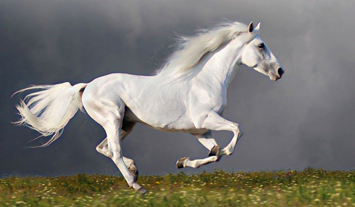

```
Epoch: 5
Total loss: 4.4030e+06, Style loss: 4.1403e+06, Content loss: 2.6277e+05
```

```python
best, best_loss,image = run_style_transfer('content.jpg',
                                     'style.jpg',epochs=9,content_weight=1e+2, style_weight=1e-3)
```

#### Evaluation

Few details have been transferred in the generated image as a result of using a single layer for both the content layer and the style layer. The upper layer of the style layer only contains basic textures, as seen in the resulting image "curve line" textures were transferred, but colour and some pattern characteristics were not. For content preservation, a content layer would only require a single layer, which was successfully maintained in this small model.

### 4.2. Model 2 : Large size model

| Model | Epochs | content_layers | style_layers | content_weight | style_weight |
| --- | --- | --- | --- | --- | --- |
| 1 | 9 | block3_conv2 | block3_conv1 | 1e+2 | 1e-3 |
| 2 | 20 | block1_conv1 | block3_conv1 | 1e+2 | 1e-3 |
|  |  | block2_conv1 | block4_conv1 |  |  |
|  |  | block5_conv1 | block5_conv1 |  |  |
|  |  | block3_conv2 | block1_conv2 |  |  |
|  |  |  | block2_conv2 |  |  |
|  |  |  | block4_conv3 |  |  |

#### Choose content and style layers

```python
#Layers used for content loss
content_layers = ['block1_conv1',
                 'block2_conv1',
                 'block5_conv1',
                 'block3_conv2']

#Layers used for style loss
style_layers = ['block3_conv1',
                'block4_conv1',
                'block5_conv1',
                'block1_conv2',
                'block2_conv2',
                'block4_conv3']

number_content = len(content_layers)
number_style = len(style_layers)
```

```python
def get_model():
    # Load our model. We load pretrained VGG, trained on imagenet data (weights=’imagenet’)
    vgg = tf.keras.applications.vgg19.VGG19(include_top=False, weights='imagenet')
    vgg.trainable = False

    # Get output layers corresponding to style and content layers
    content_output=[vgg.get_layer(layer).output for layer in content_layers]
    style_output=[vgg.get_layer(layer).output for layer in style_layers]
    model_output= style_output + content_output

     # Build model
    return models.Model(vgg.input, model_output)
```

```python
def run_style_transfer(content_path,style_path,epochs,content_weight, style_weight):

    model = get_model()

    #We don't need to (or want to) train any layers of our model, so we set their trainability to false.
    for layer in model.layers:
        layer.trainable = False

    #Get the style and content feature representations (from our specified intermediate layers)
    content_feature, style_feature = get_features(model,content_path,style_path)
    style_gram_matrix = [gram_matrix(feature) for feature in style_feature]

    #Set initial image
    init_image = preprocess_image(content_path)
    init_image = tf.Variable(init_image,dtype=tf.float32)

    #Create our optimizer
    optimizer = tf.keras.optimizers.Adam(learning_rate=5, beta_1=0.99, epsilon=1e-1)

    #Store our best result
    best_loss, best_img = float('inf'), None

    #Create a nice configuration
    loss_weights = (style_weight, content_weight)
    dictionary={'model': model,
              'loss_weights': loss_weights,
              'init_image': init_image,
              'gram_style_features': style_gram_matrix,
              'content_features': content_feature}

    norm_means = np.array([103.939, 116.779, 123.68])
    min_vals = -norm_means
    max_vals = 255 - norm_means

    imgs = []
    for i in range(epochs):
        grad,all_loss = compute_grads(dictionary)
        total_loss, style_loss, content_loss = all_loss
        optimizer.apply_gradients([(grad,init_image)])
        clipped = tf.clip_by_value(init_image,min_vals,max_vals)
        init_image.assign(clipped)

        if total_loss < best_loss:
            best_loss = total_loss
            best_img = deprocess_img(init_image.numpy())

        #for visualization
        if i%5==0:
            plot_img = init_image.numpy()
            plot_img = deprocess_img(plot_img)
            imgs.append(plot_img)
            display.clear_output(wait=True)
            display.display_png(Image.fromarray(plot_img))
            print('Epoch: {}'.format(i))
            print('Total loss: {:.4e}, '
              'Style loss: {:.4e}, '
              'Content loss: {:.4e}'.format(total_loss, style_loss, content_loss))

    display.clear_output(wait=True)


    return best_img,best_loss,imgs
```

[figure not shown]

```
Epoch: 15
Total loss: 1.7895e+07, Style loss: 1.2632e+07, Content loss: 5.2638e+06
```

```python
best, best_loss,image = run_style_transfer('content.jpg',
                                     'style.jpg',epochs = 20,content_weight=1e+2, style_weight=1e-3)
```

#### Evaluation

Due to the use of numerous layers for both the content layer and the style layer, the generated image has resulted in transfer learning with complex features.

Lower-level features such as edges and simple textures are detected by the first layers of a network. As we go higher, Layers begin to encode higher-level concepts such as more complex textures and object classes. Half of the style layers in this larger model are deeper layers, allowing higher-level features to be detected, resulting in an image with vibrant colours and rich texture and patterns.

### 4.3. Model 3

| Model | Epochs | content_layers | style_layers | content_weight | style_weight |
| --- | --- | --- | --- | --- | --- |
| 1 | 9 | block3_conv2 | block3_conv1 | 1e+2 | 1e-3 |
| 2 | 20 | block1_conv1 | block3_conv1 | 1e+2 | 1e-3 |
|  |  | block2_conv1 | block4_conv1 |  |  |
|  |  | block5_conv1 | block5_conv1 |  |  |
|  |  | block3_conv2 | block1_conv2 |  |  |
|  |  |  | block2_conv2 |  |  |
|  |  |  | block4_conv3 |  |  |
| 3 | 20 | block5_conv2 | block1_conv1 | 1e+2 | 1e-3 |
|  |  |  | block2_conv1 |  |  |
|  |  |  | block3_conv1 |  |  |
|  |  |  | block4_conv1 |  |  |
|  |  |  | block5_conv1 |  |  |

```python
#Layers used for content loss
content_layers = ['block5_conv2']

#Layers used for style loss
style_layers = ['block1_conv1',
                'block2_conv1',
                'block3_conv1',
                'block4_conv1',
                'block5_conv1']

number_content = len(content_layers)
number_style = len(style_layers)
```

```python
def get_model():
    # Load our model. We load pretrained VGG, trained on imagenet data (weights=’imagenet’)
    vgg = tf.keras.applications.vgg19.VGG19(include_top=False, weights='imagenet')
    vgg.trainable = False

    # Get output layers corresponding to style and content layers
    content_output=[vgg.get_layer(layer).output for layer in content_layers]
    style_output=[vgg.get_layer(layer).output for layer in style_layers]
    model_output= style_output + content_output

     # Build model
    return models.Model(vgg.input, model_output)
```

```python
def run_style_transfer(content_path,style_path,epochs,content_weight, style_weight):

    model = get_model()

    #We don't need to (or want to) train any layers of our model, so we set their trainability to false.
    for layer in model.layers:
        layer.trainable = False

    #Get the style and content feature representations (from our specified intermediate layers)
    content_feature, style_feature = get_features(model,content_path,style_path)
    style_gram_matrix = [gram_matrix(feature) for feature in style_feature]

    #Set initial image
    init_image = preprocess_image(content_path)
    init_image = tf.Variable(init_image,dtype=tf.float32)

    #Create our optimizer
    optimizer = tf.keras.optimizers.Adam(learning_rate=5, beta_1=0.99, epsilon=1e-1)

    #Store our best result
    best_loss, best_img = float('inf'), None

    #Create a nice configuration
    loss_weights = (style_weight, content_weight)
    dictionary={'model': model,
              'loss_weights': loss_weights,
              'init_image': init_image,
              'gram_style_features': style_gram_matrix,
              'content_features': content_feature}

    norm_means = np.array([103.939, 116.779, 123.68])
    min_vals = -norm_means
    max_vals = 255 - norm_means

    imgs = []
    for i in range(epochs):
        grad,all_loss = compute_grads(dictionary)
        total_loss, style_loss, content_loss = all_loss
        optimizer.apply_gradients([(grad,init_image)])
        clipped = tf.clip_by_value(init_image,min_vals,max_vals)
        init_image.assign(clipped)

        if total_loss < best_loss:
            best_loss = total_loss
            best_img = deprocess_img(init_image.numpy())

        #for visualization
        if i%5==0:
            plot_img = init_image.numpy()
            plot_img = deprocess_img(plot_img)
            imgs.append(plot_img)
            display.clear_output(wait=True)
            display.display_png(Image.fromarray(plot_img))
            print('Epoch: {}'.format(i))
            print('Total loss: {:.4e}, '
              'Style loss: {:.4e}, '
              'Content loss: {:.4e}'.format(total_loss, style_loss, content_loss))

    display.clear_output(wait=True)


    return best_img,best_loss,imgs
```

[figure not shown]

```
Epoch: 15
Total loss: 1.5851e+07, Style loss: 1.5497e+07, Content loss: 3.5379e+05
```

```python
best, best_loss,image = run_style_transfer('content.jpg',
                                     'style.jpg',epochs = 20,content_weight=1e+2, style_weight=1e-3)
```

#### Evaluation

We can see that by using only one content layer, we were able to reduce content loss. The single content layer preserved the content image, which is our goal. Additionally, as with the previous model, the combination of upper and lower layers for the style layers resulted in texture and colour transfer learning.

### 4.4. Model 4 : Best Model

| Model | Epochs | content_layers | style_layers | content_weight | style_weight |
| --- | --- | --- | --- | --- | --- |
| 1 | 9 | block3_conv2 | block3_conv1 | 1e+2 | 1e-3 |
| 2 | 20 | block1_conv1 | block3_conv1 | 1e+2 | 1e-3 |
|  |  | block2_conv1 | block4_conv1 |  |  |
|  |  | block5_conv1 | block5_conv1 |  |  |
|  |  | block3_conv2 | block1_conv2 |  |  |
|  |  |  | block2_conv2 |  |  |
|  |  |  | block4_conv3 |  |  |
| 3 | 20 | block5_conv2 | block1_conv1 | 1e+2 | 1e-3 |
|  |  |  | block2_conv1 |  |  |
|  |  |  | block3_conv1 |  |  |
|  |  |  | block4_conv1 |  |  |
|  |  |  | block5_conv1 |  |  |
| 4 | 20 | block5_conv2 | block1_conv1 | 1e+3 | 1e-3 |
|  |  |  | block2_conv1 |  |  |
|  |  |  | block3_conv1 |  |  |
|  |  |  | block4_conv1 |  |  |
|  |  |  | block5_conv1 |  |  |

```python
#Layers used for content loss
content_layers = ['block5_conv2']

#Layers used for style loss
style_layers = ['block1_conv1',
                'block2_conv1',
                'block3_conv1',
                'block4_conv1',
                'block5_conv1']

number_content = len(content_layers)
number_style = len(style_layers)
```

```python
def get_model():
    # Load our model. We load pretrained VGG, trained on imagenet data (weights=’imagenet’)
    vgg = tf.keras.applications.vgg19.VGG19(include_top=False, weights='imagenet')
    vgg.trainable = False

    # Get output layers corresponding to style and content layers
    content_output=[vgg.get_layer(layer).output for layer in content_layers]
    style_output=[vgg.get_layer(layer).output for layer in style_layers]
    model_output= style_output + content_output

     # Build model
    return models.Model(vgg.input, model_output)
```

```python
def run_style_transfer(content_path,style_path,epochs,content_weight, style_weight):

    model = get_model()

    #We don't need to (or want to) train any layers of our model, so we set their trainability to false.
    for layer in model.layers:
        layer.trainable = False

    #Get the style and content feature representations (from our specified intermediate layers)
    content_feature, style_feature = get_features(model,content_path,style_path)
    style_gram_matrix = [gram_matrix(feature) for feature in style_feature]

    #Set initial image
    init_image = preprocess_image(content_path)
    init_image = tf.Variable(init_image,dtype=tf.float32)

    #Create our optimizer
    optimizer = tf.keras.optimizers.Adam(learning_rate=5, beta_1=0.99, epsilon=1e-1)

    #Store our best result
    best_loss, best_img = float('inf'), None

    #Create a nice configuration
    loss_weights = (style_weight, content_weight)
    dictionary={'model': model,
              'loss_weights': loss_weights,
              'init_image': init_image,
              'gram_style_features': style_gram_matrix,
              'content_features': content_feature}

    norm_means = np.array([103.939, 116.779, 123.68])
    min_vals = -norm_means
    max_vals = 255 - norm_means

    imgs = []
    for i in range(epochs):
        grad,all_loss = compute_grads(dictionary)
        total_loss, style_loss, content_loss = all_loss
        optimizer.apply_gradients([(grad,init_image)])
        clipped = tf.clip_by_value(init_image,min_vals,max_vals)
        init_image.assign(clipped)

        if total_loss < best_loss:
            best_loss = total_loss
            best_img = deprocess_img(init_image.numpy())

        #for visualization
        if i%5==0:
            plot_img = init_image.numpy()
            plot_img = deprocess_img(plot_img)
            imgs.append(plot_img)
            display.clear_output(wait=True)
            display.display_png(Image.fromarray(plot_img))
            print('Epoch: {}'.format(i))
            print('Total loss: {:.4e}, '
              'Style loss: {:.4e}, '
              'Content loss: {:.4e}'.format(total_loss, style_loss, content_loss))

    display.clear_output(wait=True)


    return best_img,best_loss,imgs
```

[figure not shown]

```
Epoch: 15
Total loss: 1.7839e+07, Style loss: 1.5384e+07, Content loss: 2.4551e+06
```

```python
best, best_loss,image = run_style_transfer('content.jpg',
                                     'style.jpg',epochs=20,content_weight=1e+3, style_weight=1e-3)
```

## 5. Conclusion

| Model | Total loss | Style loss | Content loss |
| --- | --- | --- | --- |
| 1 | 4.4030e+06 | 4.1403e+06 | 2.6277e+05 |
| 2 | 1.7895e+07 | 1.2632e+07 | 5.2638e+06 |
| 3 | 1.5851e+07 | 1.5497e+07 | 3.5379e+05 |
| 4 | 1.7839e+07 | 1.5384e+07 | 2.4551e+06 |

## 6. References

- "Deep Learning with Python" By Francois Chollet
- https://medium.com/tensorflow/neural-style-transfer-creating-art-with-deep-learning-using-tf-keras-and-eagerexecution-7d541ac31398
- https://towardsdatascience.com/neural-style-transfer-a-high-level-approach-250d4414c56b"
- https://www.geeksforgeeks.org/neural-style-transfer-with-tensorflow/
- https://www.tensorflow.org/tutorials/generative/style_transfer
- https://towardsdatascience.com/a-neural-algorithm-of-artistic-style-a-modern-form-of-creation-d39a6ac7e715